# 005 — EDA and baseline classifier on the 004 GT-bearing feature matrix

Author

Dan MacLean

Published

April 24, 2026

## Goal

Take the feature matrix produced in notebook 004 (`results/004_full_run/feature_matrix.csv`, 44 rows × ~60 cols), apply the dedup rule recorded there, restrict to rows where the activated oligomeric state is known from the literature, and characterise the canonical 11 SNI features against the binary class

- **TP**: AF3 `predicted_oligomer == gt_oligomer`
- **FP**: AF3 `predicted_oligomer != gt_oligomer`

before fitting any classifier — sample dimensions, class balance, per-feature missingness, univariate class-separation, within-class distribution shapes, and inter-feature redundancy. After the EDA, run the same mlr3 LOOCV + permutation-null pipeline as notebook 002 on the GT-bearing subset, with α1-feature handling held to a single strategy because every GT row has the α1 features populated.

## Hypotheses

1. The GT subset after dedup will have a small number of rows (≈12) and an imbalanced class ratio (more FP than TP), since the 004 matrix carries the full NbNRC2a stoichiometry sweep (4 forced-wrong stoichiometries vs 1 correct hexamer) plus pentamer/hexamer pairs for Sr35, ZAR1, RPS2 (1 correct vs 1 forced for Sr35 and ZAR1, and 2 forced for RPS2 whose GT is octamer).
2. `D_MHD_P_mean` will be NA across every GT row — and indeed every row in the matrix — because the `--mhd_csv` annotation supplied to the pipeline only lists NbNRC2a’s MHD coordinates, and the pipeline emits NA for proteins with no annotation rather than imputing. This is the coverage gap flagged in 004 R6 / decision list item 4.
3. Of the remaining 10 canonical features, at least `S_PROTO`, `D_APEX`, `SD_THETA_ROT` and `BSA_INT_PROTO` will show visible TP/FP gaps in the row-wise observations from 004 R3 and R4, but at n = 12 with 3 TP / 9 FP no univariate test will reach conventional significance after multiple-comparison adjustment.
4. The mlr3 LOOCV pipeline’s `featureless` baseline will sit at 9/12 ≈ 0.75 accuracy by predicting the majority (FP) class on every fold. `log_reg` will not converge stably with 10 features and 12 rows; `ranger` will fit but will likely not exceed the permutation null distribution, because the null is constrained to the same 3:9 marginal and most label shuffles will themselves reach 0.75 accuracy by majority-class prediction on most folds.

## Rationale

n = 12 is small and the class ratio is not balanced, so the EDA is qualitative for almost every quantity. Despite that, the same set of EDA passes done in 001 (matrix inventory → missingness → univariate AUC → distributions → redundancy) is the right lens here because

- 1. the 004 matrix introduces a different class question (TP vs FP AF3 oligomer call) on the same canonical 11 SNI features that 001 ran on helper vs sensor, so the EDA pattern transfers directly;
- 2. writing the EDA out makes explicit how thin the GT panel is, which is the binding constraint on every claim in this and any follow-on notebook;
- 3. the baseline classifier section mirrors 002 so that the LOOCV accuracy / AUC numbers and the permutation null are reported on the same scale the helper/sensor benchmark was reported on, making the two readable side-by-side in the writeup.

The classifier section is included for parity with 002 rather than as a load-bearing result. The conclusions about feature behaviour and the decisions for 006 are drawn from the EDA, not from the classifier.

## Setup

```r
suppressPackageStartupMessages({
  library(here)
  library(dplyr)
  library(tidyr)
  library(ggplot2)
  library(knitr)
  library(mlr3)
  library(mlr3learners)
  library(mlr3pipelines)
  library(data.table)
})
lgr::get_logger("mlr3")$set_threshold("warn")

knitr::opts_chunk$set(fig.path = "../results/figures/005_")

fm <- read.csv(here("results", "004_full_run", "feature_matrix.csv"),
               stringsAsFactors = FALSE, na.strings = c("", "NA"))

# pandas wrote booleans as "True"/"False" strings — coerce back
fm$is_triple_deposit <- fm$is_triple_deposit == "True"
fm$call_correct      <- ifelse(fm$call_correct == "True", TRUE,
                        ifelse(fm$call_correct == "False", FALSE, NA))

# 004 dedup rule: keep the NRC2_hexamers nbnrc2a hexamer (n=10 seeds);
# drop the AF_benchmark and Benchmarks duplicates of the same model.
fm_dedup <- fm |>
  filter(!(archive %in% c("AF_benchmark", "Benchmarks") &
           protein == "nbnrc2a" & predicted_oligomer == 6))

gt <- fm_dedup |>
  filter(!is.na(gt_oligomer)) |>
  mutate(class = factor(ifelse(call_correct, "TP", "FP"),
                        levels = c("FP", "TP")),
         row_id = paste(protein, archive, predicted_oligomer, sep = "/"))

CANONICAL_11 <- c("ipTM_LCB", "Sum_CONTACTS", "BSA_INT_PROTO",
                  "SD_THETA_ROT", "S_PROTO", "D_APEX",
                  "THETA_APEX_mean", "L_APEX_mean", "H_ABS_mean",
                  "MU_H_mean", "D_MHD_P_mean")
```

## 1. Matrix inventory

```r
dim_tbl <- data.frame(
  matrix = c("004 raw", "004 after triple-deposit dedup",
             "GT-bearing subset (after dedup)"),
  rows   = c(nrow(fm), nrow(fm_dedup), nrow(gt)),
  cols   = c(ncol(fm), ncol(fm_dedup), ncol(gt))
)
knitr::kable(dim_tbl)
```

| matrix | rows | cols |
| --- | --- | --- |
| 004 raw | 44 | 71 |
| 004 after triple-deposit dedup | 42 | 71 |
| GT-bearing subset (after dedup) | 12 | 73 |

```r
table(class = gt$class)
```

```
class
FP TP
 9  3
```

```r
gt |>
  select(row_id, protein, archive, predicted_oligomer, gt_oligomer, class,
         N_replicates) |>
  arrange(class, protein, predicted_oligomer) |>
  knitr::kable()
```

| row_id | protein | archive | predicted_oligomer | gt_oligomer | class | N_replicates |
| --- | --- | --- | --- | --- | --- | --- |
| nbnrc2a/NRC2_tetramers/4 | nbnrc2a | NRC2_tetramers | 4 | 6 | FP | 10 |
| nbnrc2a/Benchmarks/5 | nbnrc2a | Benchmarks | 5 | 6 | FP | 1 |
| nbnrc2a/NRC2_pentamers/5 | nbnrc2a | NRC2_pentamers | 5 | 6 | FP | 10 |
| nbnrc2a/NRC2_heptamers/7 | nbnrc2a | NRC2_heptamers | 7 | 6 | FP | 10 |
| nbnrc2a/NRC2_octamers/8 | nbnrc2a | NRC2_octamers | 8 | 6 | FP | 10 |
| rps2/CCG10/5 | rps2 | CCG10 | 5 | 8 | FP | 1 |
| rps2/CCG10/6 | rps2 | CCG10 | 6 | 8 | FP | 1 |
| sr35/Benchmarks/6 | sr35 | Benchmarks | 6 | 5 | FP | 1 |
| zar1/Benchmarks/6 | zar1 | Benchmarks | 6 | 5 | FP | 1 |
| nbnrc2a/NRC2_hexamers/6 | nbnrc2a | NRC2_hexamers | 6 | 6 | TP | 10 |
| sr35/Benchmarks/5 | sr35 | Benchmarks | 5 | 5 | TP | 1 |
| zar1/Benchmarks/5 | zar1 | Benchmarks | 5 | 5 | TP | 1 |

12 rows after dedup, 3 TP and 9 FP, as anticipated. The TP cell is made of one true hexamer (NbNRC2a from `NRC2_hexamers`, the 10-seed sweep) and two true pentamers (Sr35 and ZAR1 from `Benchmarks`). The FP cell is the four forced-wrong NbNRC2a stoichiometries (tetra/penta/hepta/octa), the NbNRC2a forced-pentamer from `Benchmarks`, the Sr35 forced-hexamer, the ZAR1 forced-hexamer, and both RPS2 deposits (whose true state is octamer, so neither the penta nor the hexa deposit is correct).

## 2. Missingness patterns

### 2.1 Per-feature NA counts by class (canonical 11)

```r
na_by_class <- function(df, cols) {
  do.call(rbind, lapply(cols, function(col) {
    data.frame(
      feature  = col,
      n_FP_NA  = sum(is.na(df[df$class == "FP", col])),
      n_TP_NA  = sum(is.na(df[df$class == "TP", col])),
      n_FP     = sum(df$class == "FP"),
      n_TP     = sum(df$class == "TP"),
      row.names = NULL
    )
  }))
}

na_tbl_11 <- na_by_class(gt, CANONICAL_11)
na_tbl_11 <- na_tbl_11[order(-(na_tbl_11$n_FP_NA + na_tbl_11$n_TP_NA)), ]
knitr::kable(na_tbl_11, row.names = FALSE)
```

| feature | n_FP_NA | n_TP_NA | n_FP | n_TP |
| --- | --- | --- | --- | --- |
| D_MHD_P_mean | 9 | 3 | 9 | 3 |
| ipTM_LCB | 0 | 0 | 9 | 3 |
| Sum_CONTACTS | 0 | 0 | 9 | 3 |
| BSA_INT_PROTO | 0 | 0 | 9 | 3 |
| SD_THETA_ROT | 0 | 0 | 9 | 3 |
| S_PROTO | 0 | 0 | 9 | 3 |
| D_APEX | 0 | 0 | 9 | 3 |
| THETA_APEX_mean | 0 | 0 | 9 | 3 |
| L_APEX_mean | 0 | 0 | 9 | 3 |
| H_ABS_mean | 0 | 0 | 9 | 3 |
| MU_H_mean | 0 | 0 | 9 | 3 |

`D_MHD_P_mean` is NA in every GT row. Looking at the full 44-row matrix it is NA in every row, full stop, not just in the GT subset: the `--mhd_csv` annotation supplied to the 004 pipeline only carries NbNRC2a coordinates and the pipeline emits NA where the lookup misses. Drop the feature from any per-feature analysis below — the “canonical 11” reduces to a “canonical 10” for everything that follows.

The α1 features (`THETA_APEX_mean`, `L_APEX_mean`, `H_ABS_mean`, `MU_H_mean`) are populated for every GT row, including Sr35 and RPS2 (whose α1 values come from the DSSP fallback per 004 decision 3a). No row has any other NA in the canonical set.

### 2.2 Missingness grid (canonical 11, GT subset)

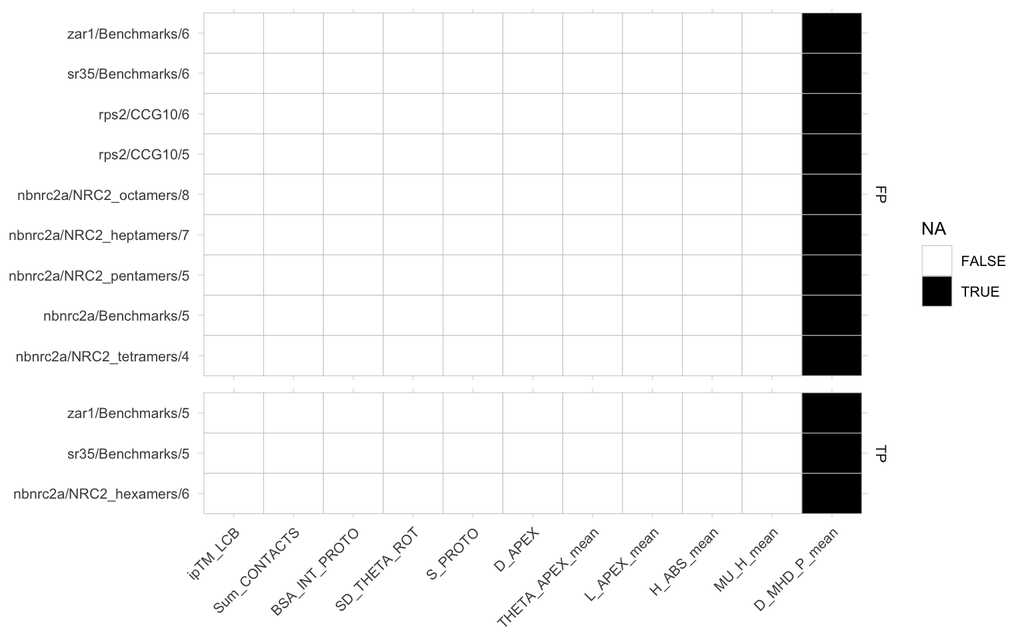

```r
na_long <- pivot_longer(
  cbind(gt[, c("row_id", "class")], is.na(gt[, CANONICAL_11])),
  cols = all_of(CANONICAL_11),
  names_to = "feature", values_to = "is_na"
)
na_long$feature <- factor(na_long$feature, levels = CANONICAL_11)
na_long$row_id  <- factor(na_long$row_id,
                          levels = gt$row_id[order(gt$class, gt$protein,
                                                   gt$predicted_oligomer)])

ggplot(na_long, aes(x = feature, y = row_id, fill = is_na)) +
  geom_tile(colour = "grey80") +
  scale_fill_manual(values = c(`FALSE` = "white", `TRUE` = "black")) +
  facet_grid(class ~ ., scales = "free_y", space = "free_y") +
  theme_minimal(base_size = 10) +
  theme(axis.text.x = element_text(angle = 45, hjust = 1)) +
  labs(x = NULL, y = NULL, fill = "NA")
```

`D_MHD_P_mean` shows as a black column across both classes; every other feature is white throughout. From here on the active feature set is the canonical 10:

```r
CANONICAL_10 <- setdiff(CANONICAL_11, "D_MHD_P_mean")
CANONICAL_10
```

```
 [1] "ipTM_LCB"        "Sum_CONTACTS"    "BSA_INT_PROTO"   "SD_THETA_ROT"
 [5] "S_PROTO"         "D_APEX"          "THETA_APEX_mean" "L_APEX_mean"
 [9] "H_ABS_mean"      "MU_H_mean"
```

## 3. Univariate class-separation (rank AUC)

Same Mann–Whitney rank-AUC ranker as notebook 001: `U / (n_TP * n_FP)`, NAs dropped, positive class = TP. Raw AUC is directional (high → feature value tends to be larger in TP than FP); `auc_abs = max(auc, 1 - auc)` is the direction-free separation.

```r
univariate_auc <- function(x, y, positive = "TP") {
  mask  <- !is.na(x)
  x     <- x[mask]; y <- y[mask]
  n_pos <- sum(y == positive); n_neg <- sum(y != positive)
  if (n_pos < 1 || n_neg < 1) {
    return(data.frame(auc = NA_real_, auc_abs = NA_real_,
                      n_used = length(x), n_pos = n_pos, n_neg = n_neg,
                      wilcox_p = NA_real_))
  }
  r <- rank(c(x[y == positive], x[y != positive]))
  U <- sum(r[seq_len(n_pos)]) - n_pos * (n_pos + 1) / 2
  auc <- U / (n_pos * n_neg)
  p   <- tryCatch(
    suppressWarnings(wilcox.test(x ~ y)$p.value),
    error = function(e) NA_real_
  )
  data.frame(auc = auc, auc_abs = max(auc, 1 - auc),
             n_used = length(x), n_pos = n_pos, n_neg = n_neg,
             wilcox_p = p)
}

auc_table <- function(df, cols) {
  do.call(rbind, lapply(cols, function(col) {
    res <- univariate_auc(df[[col]], df$class)
    cbind(feature = col, res)
  }))
}

auc_10 <- auc_table(gt, CANONICAL_10)
auc_10 <- auc_10[order(-auc_10$auc_abs), ]
knitr::kable(auc_10, row.names = FALSE, digits = 3)
```

| feature | auc | auc_abs | n_used | n_pos | n_neg | wilcox_p |
| --- | --- | --- | --- | --- | --- | --- |
| SD_THETA_ROT | 0.037 | 0.963 | 12 | 3 | 9 | 0.018 |
| ipTM_LCB | 0.759 | 0.759 | 12 | 3 | 9 | 0.229 |
| S_PROTO | 0.259 | 0.741 | 12 | 3 | 9 | 0.282 |
| BSA_INT_PROTO | 0.704 | 0.704 | 12 | 3 | 9 | 0.373 |
| D_APEX | 0.333 | 0.667 | 12 | 3 | 9 | 0.482 |
| Sum_CONTACTS | 0.630 | 0.630 | 12 | 3 | 9 | 0.600 |
| MU_H_mean | 0.370 | 0.630 | 12 | 3 | 9 | 0.553 |
| L_APEX_mean | 0.444 | 0.556 | 12 | 3 | 9 | 0.843 |
| H_ABS_mean | 0.444 | 0.556 | 12 | 3 | 9 | 0.864 |
| THETA_APEX_mean | 0.481 | 0.519 | 12 | 3 | 9 | 1.000 |

Two things to take from this table.

First, **the per-feature separation is much weaker here than in notebook 001’s helper-vs-sensor task on the same canonical features.** In 001 six of the canonical features (`ipTM_LCB`, `Sum_CONTACTS`, `BSA_INT_PROTO`, `SD_THETA_ROT`, `S_PROTO`, `D_APEX`) ranked helpers above sensors *perfectly* — AUC = 1.0. Here only `SD_THETA_ROT` gets close to that (auc_abs ≈ 0.96), and the rest sit between 0.52 and 0.76. Telling a real-stoichiometry call from a forced-wrong one is a tighter ask of these features than telling a helper protein from a sensor protein, and it shows.

The α1 features sit lower in the ranking because their values barely move across the NbNRC2a sweep (the α1 helix doesn’t really shift when the ring size changes), so they can’t separate within-protein TP from within-protein FP for the protein that contributes most of the rows.

## 4. Feature distributions by class

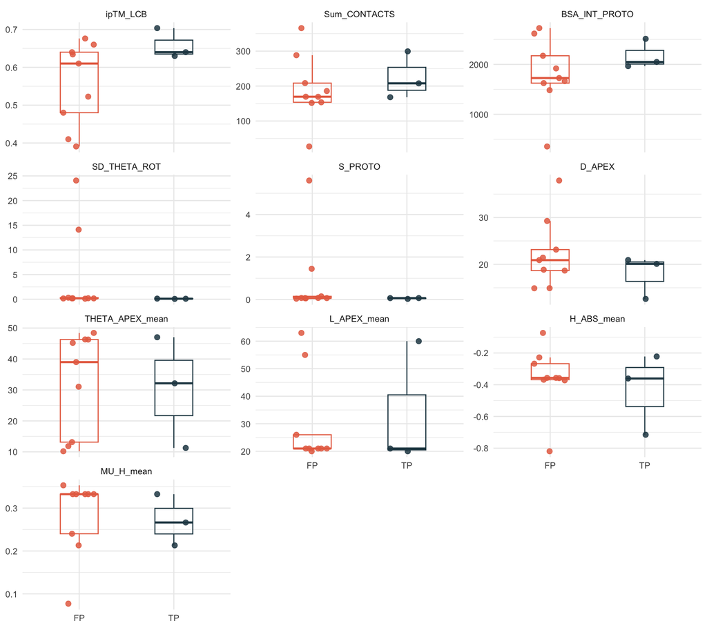

```r
long_10 <- pivot_longer(
  gt, cols = all_of(CANONICAL_10),
  names_to = "feature", values_to = "value"
)
long_10$feature <- factor(long_10$feature, levels = CANONICAL_10)

ggplot(long_10, aes(x = class, y = value, colour = class)) +
  geom_jitter(width = 0.2, height = 0, alpha = 0.85, size = 2, na.rm = TRUE) +
  geom_boxplot(outlier.shape = NA, fill = NA, width = 0.4, na.rm = TRUE) +
  facet_wrap(~ feature, scales = "free_y", ncol = 3) +
  scale_colour_manual(values = c(FP = "#e76f51", TP = "#264653")) +
  theme_minimal(base_size = 10) +
  theme(legend.position = "none") +
  labs(x = NULL, y = NULL)
```

## 5. Inter-feature redundancy

Spearman, same as 001. The pairs found redundant on the helper/sensor benchmark in 001 are expected to remain redundant here (the correlations are between features, not between features and labels).

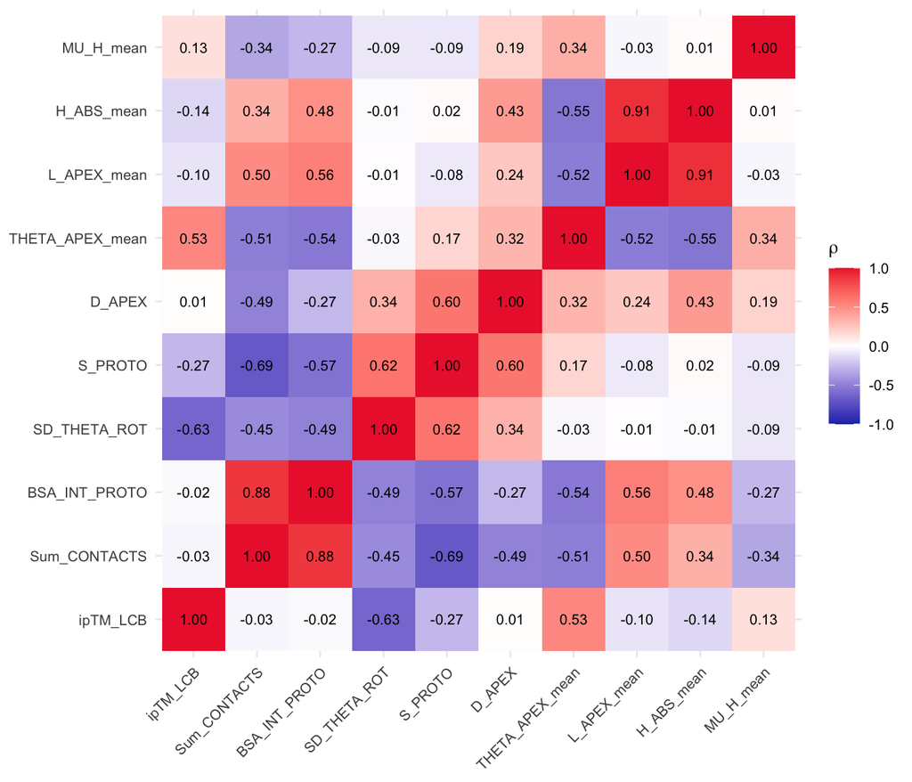

```r
cor_10 <- suppressWarnings(
  cor(gt[, CANONICAL_10], use = "pairwise.complete.obs", method = "spearman")
)

cor_long_10 <- as.data.frame(as.table(cor_10))
names(cor_long_10) <- c("x", "y", "rho")

ggplot(cor_long_10, aes(x = x, y = y, fill = rho)) +
  geom_tile() +
  geom_text(aes(label = sprintf("%.2f", rho)), size = 2.8) +
  scale_fill_gradient2(low = "#1C39BB", mid = "white", high = "#ED2939",
                       midpoint = 0, limits = c(-1, 1)) +
  theme_minimal(base_size = 10) +
  theme(axis.text.x = element_text(angle = 45, hjust = 1)) +
  labs(x = NULL, y = NULL, fill = expression(rho))
```

```r
upper_pairs <- function(M, threshold = 0.9) {
  idx <- which(abs(M) >= threshold & upper.tri(M), arr.ind = TRUE)
  if (nrow(idx) == 0) return(data.frame(a = character(), b = character(),
                                        rho = numeric()))
  data.frame(
    a   = rownames(M)[idx[, 1]],
    b   = colnames(M)[idx[, 2]],
    rho = round(M[idx], 3),
    row.names = NULL
  )[order(-abs(M[idx])), ]
}
knitr::kable(upper_pairs(cor_10, 0.9), row.names = FALSE,
             caption = "High-correlation pairs (|rho| >= 0.9)")
```

High-correlation pairs (|rho| >= 0.9)

| a | b | rho |
| --- | --- | --- |
| L_APEX_mean | H_ABS_mean | 0.905 |

Two points to keep in mind when reading this matrix: the NbNRC2a stoichiometry sweep contributes 5 of the 12 rows, all from one protein, so any pair of features that varies smoothly with chain count will look strongly correlated here just from that stoichiometry arc. And with n = 12 the correlation estimates have wide CIs; only near-perfect correlations should be acted on.

## 6. Baseline classifier (mlr3 LOOCV)

Same scaffolding as notebook 002, restricted to the canonical 10 because `D_MHD_P_mean` is NA throughout. One feature subset (`canonical_10`) and three learners — `featureless` (no-info baseline), `log_reg` (linear), `ranger` (random forest, 200 trees). LOOCV over the 12-row GT subset, scoring accuracy as the per-fold mean and AUC on the pooled prediction.

```r
make_task <- function(data, features, target = "class") {
  d <- as.data.frame(data[, c(target, features), drop = FALSE])
  TaskClassif$new(id = "sni_qc", backend = d, target = target,
                  positive = "TP")
}

build_learner <- function(lrn_id) {
  base <- lrn(lrn_id, predict_type = "prob")
  if (lrn_id == "classif.ranger") base$param_set$values$num.trees <- 200
  base
}

run_loocv <- function(data, features, lrn_id) {
  tsk <- make_task(data, features)
  lrn_obj <- build_learner(lrn_id)
  rr <- suppressWarnings(resample(tsk, lrn_obj, rsmp("loo")))
  acc_mean <- rr$aggregate(msr("classif.acc"))
  auc_pool <- tryCatch(rr$prediction()$score(msr("classif.auc")),
                       error = function(e) NA_real_)
  list(rr = rr,
       agg = c(classif.acc = unname(acc_mean),
               classif.auc = unname(auc_pool)))
}
```

```r
LEARNERS <- c("classif.featureless", "classif.log_reg", "classif.ranger")

set.seed(1)
bench_results <- do.call(rbind, lapply(LEARNERS, function(lrn_id) {
  res <- tryCatch(
    run_loocv(gt, CANONICAL_10, lrn_id),
    error = function(e) list(agg = c(classif.acc = NA_real_,
                                     classif.auc = NA_real_))
  )
  data.frame(
    cell    = "canonical_10",
    learner = sub("^classif\\.", "", lrn_id),
    acc     = unname(res$agg["classif.acc"]),
    auc     = unname(res$agg["classif.auc"])
  )
}))

knitr::kable(bench_results, digits = 3)
```

| cell | learner | acc | auc |
| --- | --- | --- | --- |
| canonical_10 | featureless | 0.750 | 0.000 |
| canonical_10 | log_reg | 0.417 | 0.481 |
| canonical_10 | ranger | 0.667 | 0.370 |

`featureless` hits 0.75 accuracy without using any feature values at all — it just predicts “FP” on every row, and because 9 of the 12 rows are FP, it gets 9 right. This is the baseline to beat. 0.75 on this data means “I learned nothing from the features”; it is not a 75% real classifier.

`log_reg` and `ranger` are the actual attempts at a classifier using the 10 SNI features. What we want to see is them scoring clearly above 0.75. The question of whether they do is settled against the permutation null in section 7, not by reading this table directly — because at n = 12 with 9 FP, accuracies near 0.75 happen very easily under random labels too.

```r
held_out <- function(data, features, lrn_id) {
  tsk <- make_task(data, features)
  lrn_obj <- build_learner(lrn_id)
  rr <- suppressWarnings(resample(tsk, lrn_obj, rsmp("loo")))
  pred_dt <- as.data.table(rr$prediction())
  pred_dt$row_id <- data$row_id[pred_dt$row_ids]
  pred_dt$class  <- data$class[pred_dt$row_ids]
  pred_dt[, .(row_id, class, response, prob_TP = prob.TP)]
}

ho_ranger <- held_out(gt, CANONICAL_10, "classif.ranger")
ho_ranger$learner <- "ranger"
ho_logreg <- tryCatch({
  d <- held_out(gt, CANONICAL_10, "classif.log_reg")
  d$learner <- "log_reg"
  d
}, error = function(e) NULL)

ho_all <- if (!is.null(ho_logreg)) rbind(ho_ranger, ho_logreg) else ho_ranger
ho_all <- ho_all[order(ho_all$learner, ho_all$class, -ho_all$prob_TP)]
knitr::kable(ho_all, digits = 3)
```

| row_id | class | response | prob_TP | learner |
| --- | --- | --- | --- | --- |
| nbnrc2a/NRC2_tetramers/4 | FP | TP | 1.000 | log_reg |
| zar1/Benchmarks/6 | FP | TP | 1.000 | log_reg |
| rps2/CCG10/5 | FP | TP | 1.000 | log_reg |
| nbnrc2a/NRC2_pentamers/5 | FP | TP | 1.000 | log_reg |
| nbnrc2a/NRC2_heptamers/7 | FP | TP | 1.000 | log_reg |
| sr35/Benchmarks/6 | FP | FP | 0.000 | log_reg |
| rps2/CCG10/6 | FP | FP | 0.000 | log_reg |
| nbnrc2a/Benchmarks/5 | FP | FP | 0.000 | log_reg |
| nbnrc2a/NRC2_octamers/8 | FP | FP | 0.000 | log_reg |
| sr35/Benchmarks/5 | TP | TP | 1.000 | log_reg |
| nbnrc2a/NRC2_hexamers/6 | TP | FP | 0.000 | log_reg |
| zar1/Benchmarks/5 | TP | FP | 0.000 | log_reg |
| nbnrc2a/NRC2_heptamers/7 | FP | FP | 0.476 | ranger |
| rps2/CCG10/6 | FP | FP | 0.434 | ranger |
| rps2/CCG10/5 | FP | FP | 0.383 | ranger |
| sr35/Benchmarks/6 | FP | FP | 0.347 | ranger |
| zar1/Benchmarks/6 | FP | FP | 0.245 | ranger |
| nbnrc2a/NRC2_pentamers/5 | FP | FP | 0.243 | ranger |
| nbnrc2a/Benchmarks/5 | FP | FP | 0.209 | ranger |
| nbnrc2a/NRC2_tetramers/4 | FP | FP | 0.107 | ranger |
| nbnrc2a/NRC2_octamers/8 | FP | FP | 0.097 | ranger |
| zar1/Benchmarks/5 | TP | FP | 0.303 | ranger |
| sr35/Benchmarks/5 | TP | FP | 0.187 | ranger |
| nbnrc2a/NRC2_hexamers/6 | TP | FP | 0.127 | ranger |

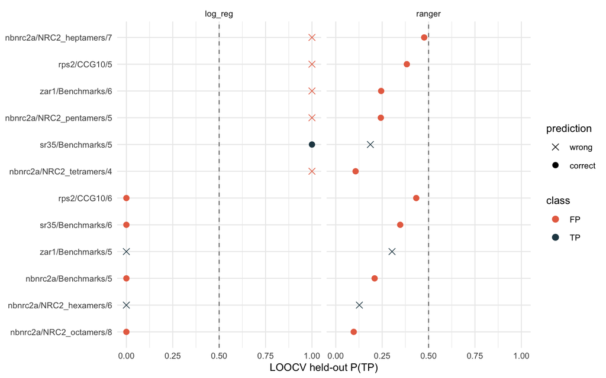

```r
ggplot(ho_all, aes(x = prob_TP, y = reorder(row_id, prob_TP),
                   colour = class, shape = response == class)) +
  geom_vline(xintercept = 0.5, linetype = "dashed", colour = "grey50") +
  geom_point(size = 2.5) +
  facet_wrap(~ learner) +
  scale_colour_manual(values = c(FP = "#e76f51", TP = "#264653")) +
  scale_shape_manual(values = c(`TRUE` = 16, `FALSE` = 4),
                     labels = c(`TRUE` = "correct", `FALSE` = "wrong"),
                     name = "prediction") +
  labs(x = "LOOCV held-out P(TP)", y = NULL) +
  theme_minimal(base_size = 10)
```

The held-out plot shows where the per-row predictions sit relative to the 0.5 boundary. With 12 rows it is short enough to read row by row.

## 7. Permutation null distribution

Class labels are permuted across the 12 GT rows and the LOOCV pipeline is re-run on each shuffle. `n_perms = 200`, ranger learner. Empirical one-sided p-value is `(1 + sum(null >= obs)) / (n_perms + 1)`, floor 1/201 ≈ 0.005.

The shuffling preserves the 3:9 marginal, so the null distribution itself sits not at 0.5 but at whatever accuracy the ranger pipeline reaches under random labels with this marginal. The null is the right calibration for the observed score.

```r
N_PERMS <- 200
PERM_CACHE <- here("results", "005_permutation_results.rds")

run_permutations <- function(data, features, lrn_id, n_perms, seed) {
  set.seed(seed)
  out <- matrix(NA_real_, nrow = n_perms, ncol = 2,
                dimnames = list(NULL, c("acc", "auc")))
  for (i in seq_len(n_perms)) {
    d_perm <- data
    d_perm$class <- sample(d_perm$class)
    res <- tryCatch(
      run_loocv(d_perm, features, lrn_id),
      error = function(e) list(agg = c(classif.acc = NA_real_,
                                       classif.auc = NA_real_))
    )
    out[i, ] <- c(res$agg["classif.acc"], res$agg["classif.auc"])
  }
  as.data.frame(out)
}

if (file.exists(PERM_CACHE)) {
  perm_results <- readRDS(PERM_CACHE)
  message("Loaded cached permutation results from ", PERM_CACHE)
} else {
  message("Running ", N_PERMS, " permutations (ranger)...")
  t0 <- Sys.time()
  obs   <- run_loocv(gt, CANONICAL_10, "classif.ranger")$agg
  nulls <- run_permutations(gt, CANONICAL_10, "classif.ranger",
                            N_PERMS, seed = 105)
  perm_results <- list(cell = "canonical_10", obs = obs, nulls = nulls)
  saveRDS(perm_results, PERM_CACHE)
  message("Done in ", round(as.numeric(difftime(Sys.time(), t0, units = "secs"))),
          " s")
}
```

```r
perm_summary <- data.frame(
  cell          = perm_results$cell,
  obs_acc       = unname(perm_results$obs["classif.acc"]),
  obs_auc       = unname(perm_results$obs["classif.auc"]),
  null_acc_mean = mean(perm_results$nulls$acc, na.rm = TRUE),
  null_auc_mean = mean(perm_results$nulls$auc, na.rm = TRUE),
  p_acc = (1 + sum(perm_results$nulls$acc >= perm_results$obs["classif.acc"],
                   na.rm = TRUE)) /
          (sum(!is.na(perm_results$nulls$acc)) + 1),
  p_auc = (1 + sum(perm_results$nulls$auc >= perm_results$obs["classif.auc"],
                   na.rm = TRUE)) /
          (sum(!is.na(perm_results$nulls$auc)) + 1)
)
knitr::kable(perm_summary, digits = 3, row.names = FALSE)
```

| cell | obs_acc | obs_auc | null_acc_mean | null_auc_mean | p_acc | p_auc |
| --- | --- | --- | --- | --- | --- | --- |
| canonical_10 | 0.75 | 0.333 | 0.698 | 0.3 | 0.458 | 0.418 |

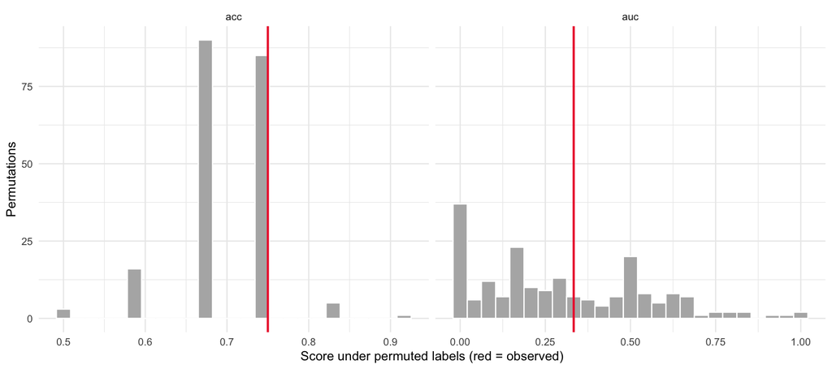

```r
nulls_long <- data.frame(
  metric = rep(c("acc", "auc"), each = nrow(perm_results$nulls)),
  value  = c(perm_results$nulls$acc, perm_results$nulls$auc)
)
obs_long <- data.frame(
  metric = c("acc", "auc"),
  value  = unname(c(perm_results$obs["classif.acc"],
                    perm_results$obs["classif.auc"]))
)

ggplot(nulls_long, aes(x = value)) +
  geom_histogram(bins = 25, fill = "grey70", colour = "white") +
  geom_vline(data = obs_long, aes(xintercept = value),
             colour = "#ED2939", linewidth = 0.8) +
  facet_wrap(~ metric, scales = "free_x") +
  labs(x = "Score under permuted labels (red = observed)",
       y = "Permutations") +
  theme_minimal(base_size = 10)
```

## 8. Conclusion

Put together: **low n, low per-feature signal on this particular question, and an unbalanced class split where most of the FP side is pseudo-replicated within one protein.** None of these is the kind of thing more modelling effort fixes on its own. What would move the needle is more experimentally-determined NLR oligomeric states from independent proteins — widening the panel past the four we currently have — and that is a data-collection problem, not a classifier problem.

## 9. Decisions / next moves for 006

- **Class definition stays as TP vs FP `call_correct`** for any follow-on classifier work in 006. The narrower `predicted_oligomer == 6` subset (the 6mer-FP question proper) is n = 4 in this matrix and not large enough to fit anything against.
- **Drop `D_MHD_P_mean` from the active feature set** until and unless the `--mhd_csv` annotation is extended to non-NRC proteins (decision item 4a from 004). 006 should run on the canonical 10.
- **Carry the per-seed JSONs into 006** for the NRC2 archives (`results/004_full_run/NRC2_*/per_structure_json/<id>_seed<N>_results.json`): the 50 per-seed NbNRC2a rows are the right input for any seed-aware modelling, and they raise the effective row count for the only protein with a full stoichiometry sweep.
- **Keep `Benchmarks` Sr35 and ZAR1 pentamer rows as TP, hexamer rows as FP** — the across-protein TP/FP signal that 006 is supposed to test rests on these.